# Exploratory Factor Analysis

## 1 Two critics, one quality

## Two critics, one quality

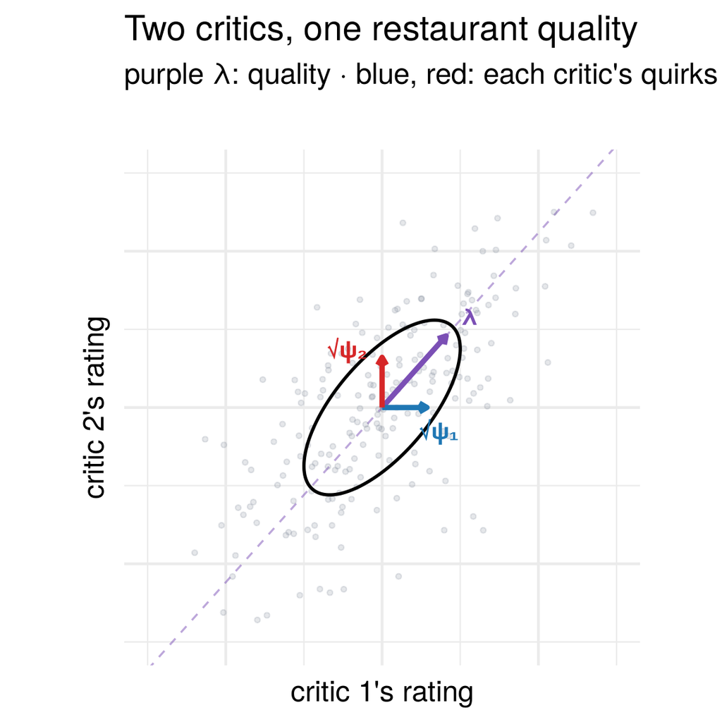

Both critics taste the same food, the restaurant’s **quality** \(f_t\).

\[ \begin{aligned} x_{t1}&=\lambda_1f_t+u_{t1}\\ x_{t2}&=\lambda_2f_t+u_{t2} \end{aligned} \]

Each critic’s **quirks** \(u_{ti}\), with variance \(\psi_i\), move only her own rating.

## Only quality creates covariance

\[ \operatorname{Var}(x_{t1})=\lambda_1^2+\psi_1,\qquad \operatorname{Var}(x_{t2})=\lambda_2^2+\psi_2,\qquad \operatorname{Cov}(x_{t1},x_{t2})=\lambda_1\lambda_2 \]

The quirks add to the variances only, so the ratings move together because of quality alone. Three numbers, four parameters (\(\lambda_1,\lambda_2,\psi_1,\psi_2\)): one **restriction** is needed to identify the parameters.

\[ \begin{pmatrix}x_{t1}\\ x_{t2}\end{pmatrix} =\begin{pmatrix}\lambda_1&\sqrt{\psi_1}&0\\ \lambda_2&0&\sqrt{\psi_2}\end{pmatrix} \begin{pmatrix}f_t\\ \varepsilon_{t1}\\ \varepsilon_{t2}\end{pmatrix} \]

Three shocks drive two ratings, so \(A\) has more columns than rows: the **shocks** are not identified, even when the parameters are.

Critic \(i\)’s **communality** \(h_i=\lambda_i^2/\operatorname{Var}(x_{ti})\) is the share of her rating variance that comes from quality, her **uniqueness** \(1-h_i\) the share from her quirks.

## Every split of the noise fits

[interactive chart not shown]

\(\operatorname{Var}(f\mid\mathbf x)\) is how uncertain quality remains once both ratings are known.

## Four natural restrictions

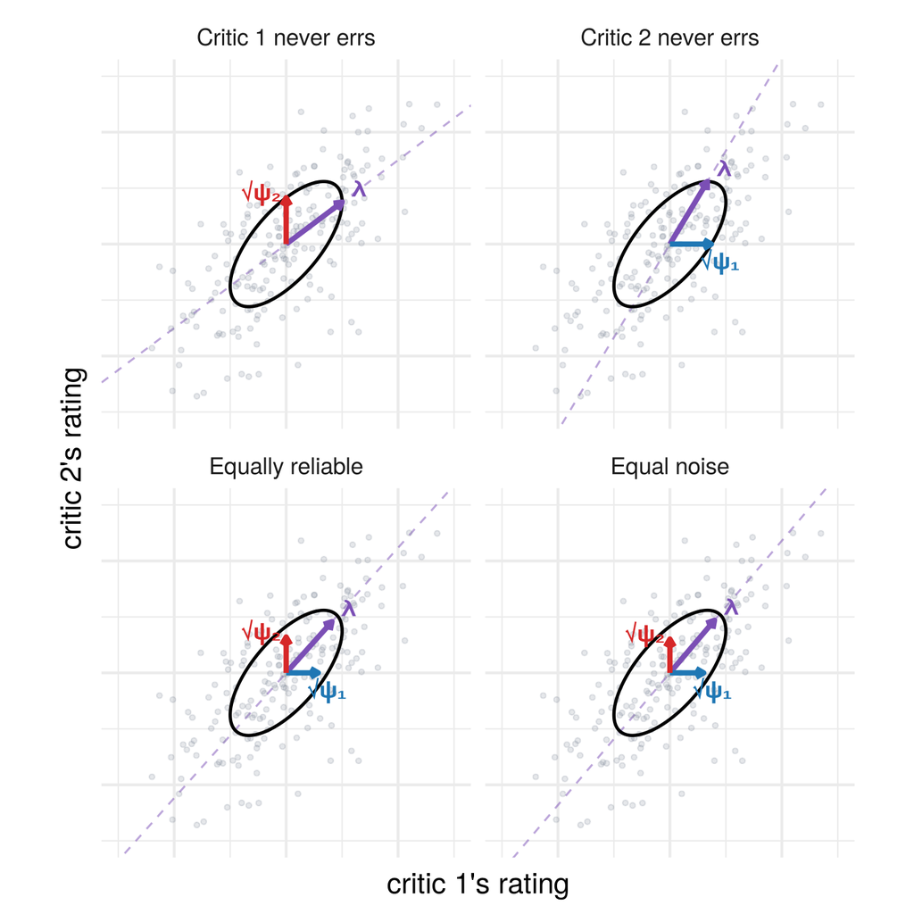

- **Critic 1 never errs**, \(\psi_1=0\). Her rating is the quality. This is Cholesky.
- **Critic 2 never errs**, \(\psi_2=0\).
- **Equally reliable**, \(h_1=h_2\). Quality explains the same share of each rating.
- **Equal noise**, \(\psi_1=\psi_2\).

## 2 The factor model

## Four critics, one quality

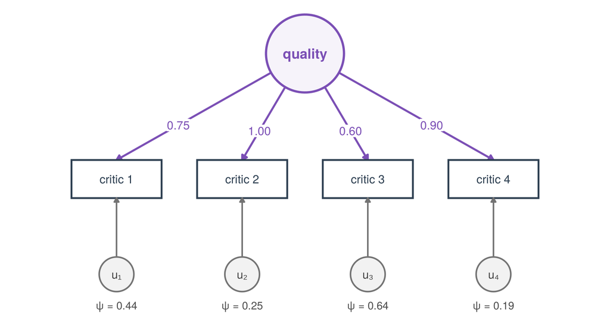

Each rating is quality times a loading, plus the critic’s own quirks, \(x_{ti}=\lambda_if_t+u_{ti}\).

## Many variables, several factors

With \(p\) variables and \(k\) factors, each variable responds to every factor:

\[x_{ti}=\lambda_{i1}f_{t1}+\dots+\lambda_{ik}f_{tk}+u_{ti},\qquad i=1,\dots,p\]

Stacked, this is the **factor model**

\[ \underbrace{\begin{pmatrix}x_{t1}\\ \vdots\\ x_{tp}\end{pmatrix}}_{\mathbf x_t} =\underbrace{\begin{pmatrix}\lambda_{11}&\cdots&\lambda_{1k}\\ \vdots&&\vdots\\ \lambda_{p1}&\cdots&\lambda_{pk}\end{pmatrix}}_{\Lambda} \underbrace{\begin{pmatrix}f_{t1}\\ \vdots\\ f_{tk}\end{pmatrix}}_{\mathbf f_t} +\underbrace{\begin{pmatrix}u_{t1}\\ \vdots\\ u_{tp}\end{pmatrix}}_{\mathbf u_t}, \qquad \Sigma=\Lambda\Lambda'+\Psi \]

\(\Lambda\) holds the loadings, and \(\Psi\) the unique variances on its diagonal.

## Only quality creates covariance

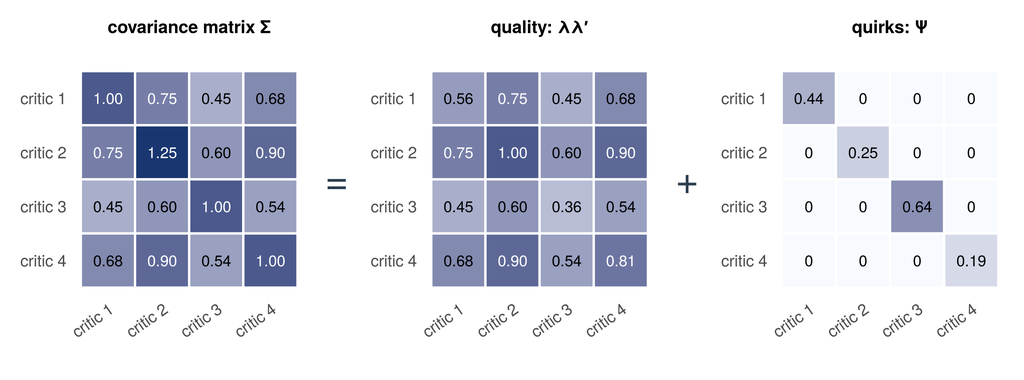

Every covariance is a product of two loadings, \(\sigma_{ij}=\lambda_i\lambda_j\). The quirks only add to the variances.

## Two critics: a whole curve fits

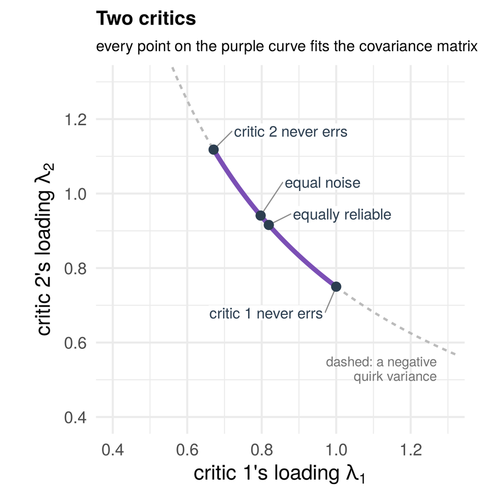

The data fix only the product \(\lambda_1\lambda_2=0.75\).

**Critic 2 never errs**, \(\psi_2=0\): then \(\operatorname{Var}(x_{t2})=\lambda_2^2=1.25\), so \(\lambda_2=1.12\) and \(\lambda_1=0.75/1.12=0.67\).

**Critic 1 never errs**, \(\psi_1=0\): \(\lambda_1=1.00\) and \(\lambda_2=0.75\).

Every point in between fits equally well.

## A third critic picks one point

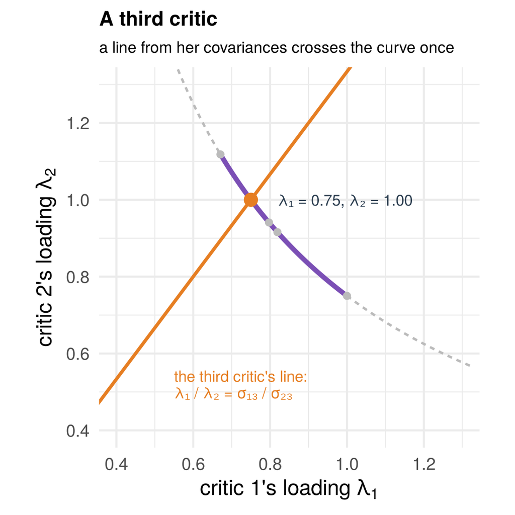

Her covariances with critics 1 and 2 are products of loadings too: \(\sigma_{13}=\lambda_1\lambda_3=0.45\) and \(\sigma_{23}=\lambda_2\lambda_3=0.60\).

Dividing one by the other cancels \(\lambda_3\), so

\[\frac{\lambda_1}{\lambda_2}=\frac{\sigma_{13}}{\sigma_{23}}=\frac{0.45}{0.60}=0.75\]

The line crosses the curve once. So three critics pin the loadings down.

## An impossible answer

Suppose critics 2 and 3 agreed much less: \(\sigma_{23}=0.25\) instead of \(0.60\).

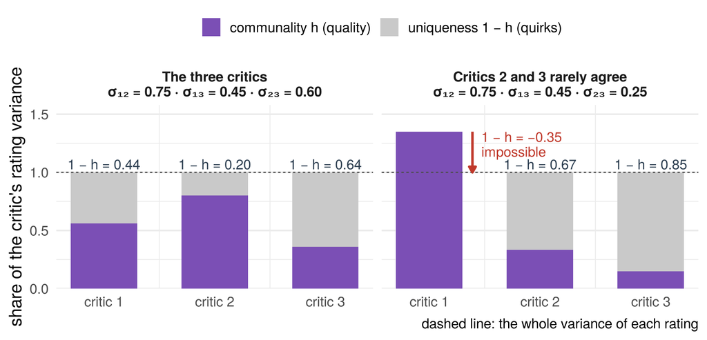

\[\lambda_1^2=\frac{(\lambda_1\lambda_2)(\lambda_1\lambda_3)}{\lambda_2\lambda_3}=\frac{\sigma_{12}\,\sigma_{13}}{\sigma_{23}}=\frac{0.75\times0.45}{0.25}=1.35>\operatorname{Var}(x_{t1})=1\]

Her uniqueness would be negative. Such an impossible answer is called a **Heywood case**.

## Why? One factor is too few

With one factor, critics agree only through quality. Critics 2 and 3 barely agree, so quality must matter little for them. Then they cannot both agree closely with critic 1.

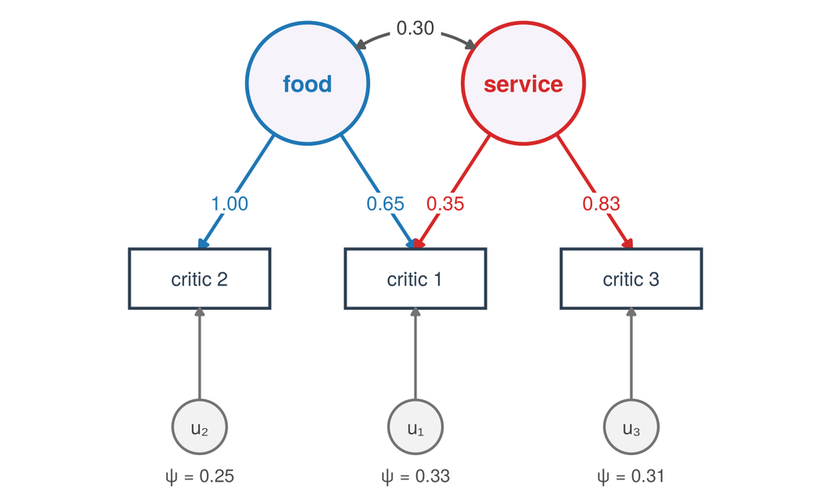

Two factors fit the same covariances: critic 1 judges food and service, critic 2 the food, critic 3 the service.

With three variables no test can tell: one factor has df = 0, and two are not identified (this is one of many stories that fit). With more variables the **likelihood ratio test** picks the number of factors.

## 3 Testing the model

## How many restrictions?

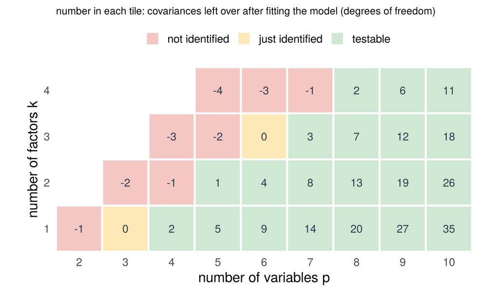

Each tile counts the covariances left over after fitting the model. Green tiles can be tested.

## Testing the tetrad conditions

A **tetrad** is a group of four. With one factor, any four variables satisfy \(\sigma_{12}\sigma_{34}=\sigma_{13}\sigma_{24}=\sigma_{14}\sigma_{23}\), since each product is \(\lambda_1\lambda_2\lambda_3\lambda_4\).

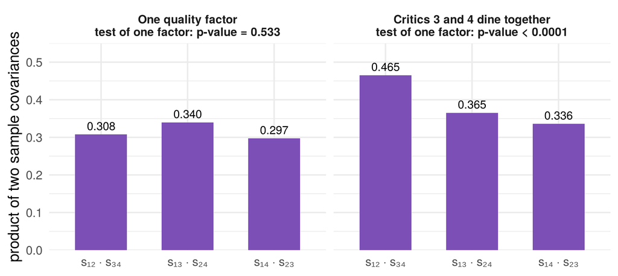

With one factor, the three products agree up to noise. When critics 3 and 4 dine together, one product sticks out and the test rejects.

Any model in the green “testable” area of the previous graph can be tested: the **likelihood ratio test** compares the fitted \(\Lambda\Lambda'+\Psi\) with \(S\) and gives the p-values above. To choose the number of factors, add factors until it no longer rejects.

## The units do not matter

Put critic 1 on a 100- instead of a 10-point scale: \(10\,x_{t1}=(10\lambda_1)\,f_t+10\sqrt{\psi_1}\,\varepsilon_{t1}\)

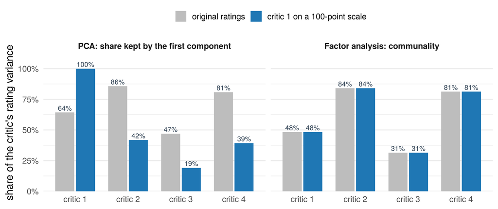

**Factor analysis** is **scale-invariant**: her common and unique parts both grow 100-fold (her loading 10-fold), so the factor, the communalities, the fit and the test stay the same.

**PCA** chases variance: hers grows 100-fold, and the first component becomes almost her rating alone. So PCA is usually run on the correlation matrix.

## 4 Two factors and rotation

## A new example: six tests, two abilities

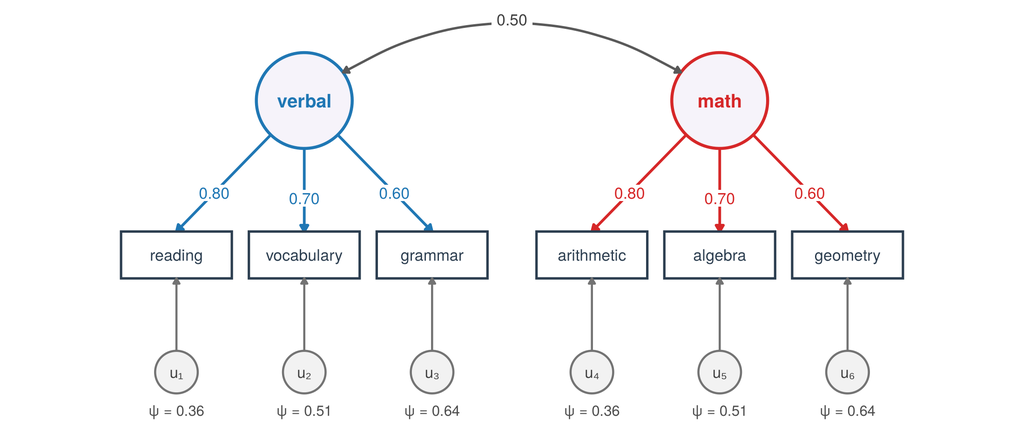

How the scores are **simulated**: each test depends on one ability, and the abilities are correlated (0.5). The analysis sees only the six **observed** scores, not the **latent** abilities. The likelihood ratio test rejects one factor (p-value below 0.0001) but not two (0.81), so we keep two.

## Every turn of the factors fits

[interactive chart not shown]

Turning the factors moves all six tests together.

No correlation and no communality changes. So the data cannot choose the turn.

**Varimax** picks the turn where each test loads mainly on one factor, a *simple structure*: press “varimax”.

## Three choices of axes

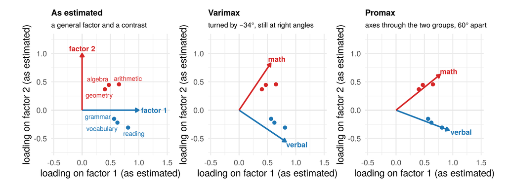

R was never told which test is which. The data find the two groups, and we name the factors.

Uncorrelated factors cannot match correlated abilities, so small cross-loadings remain after varimax. Promax tilts the axes through the groups, and its factors have a correlation of 0.50.

## 5 Factor scores

## Parameters yes, shocks no

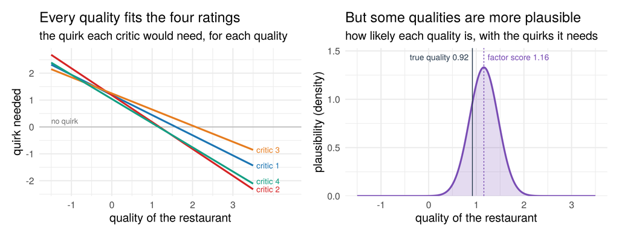

Four ratings, five shocks. \(A\) has more columns than rows, so no inverse recovers the quality.

The peak is not where the quirks average zero: a quirk counts more for a critic whose quirks are usually small, and a quality far above average is itself unlikely.

## Estimating the quality

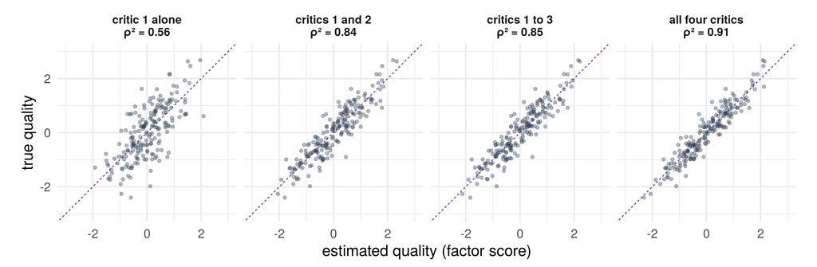

Each critic counts in proportion to her loading over her quirk variance. Even four critics pin quality down only to \(\rho^2=0.91\).

\(\rho^2\): the squared correlation between the estimated and the true quality, the share of the variance of quality that the ratings explain.

## 6 Real data, and PCA

## The US states: PCA and factor analysis

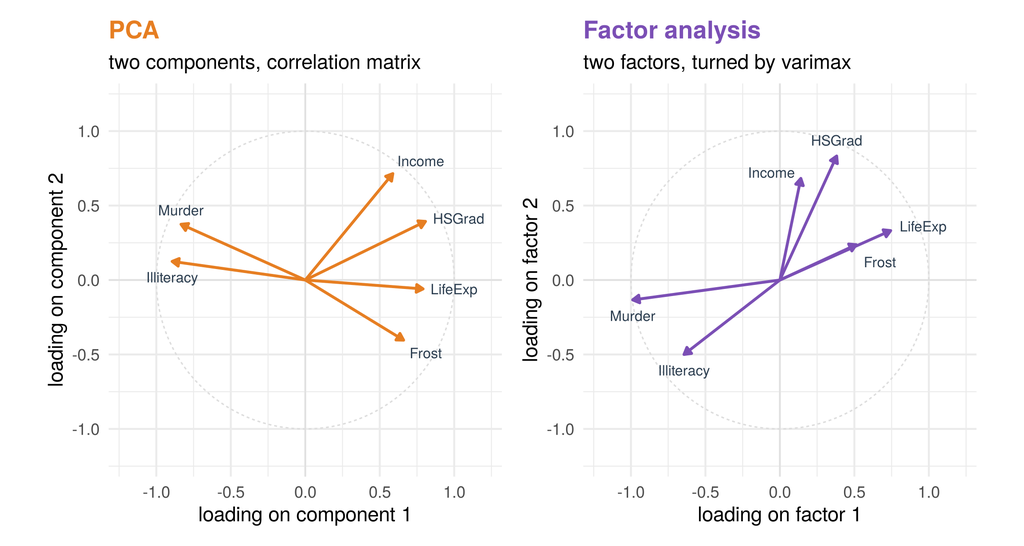

PCA uses the correlation matrix, since the indicators have different units. Much the same fan of arrows, turned. The tests reject two factors, and murder’s uniqueness is 0.005, the lowest value `factanal()` allows: a Heywood case.

## What counts as common

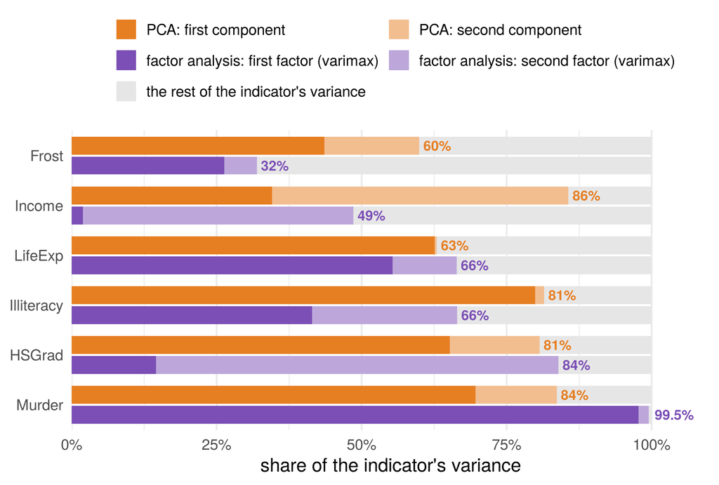

PCA keeps more of frost and income than the factors explain: its components also take in part of their unique variance.

Dark: first component or factor, light: second. The numbers are the totals, which no turn of the factors changes.

## Takeaways

- A factor model explains the **covariances** by a few common factors.
- One factor needs **three** variables. A fourth makes the model **testable**.
- Two or more factors can be **turned** without changing the fit. **Varimax** picks the turn where each variable loads mainly on one factor, and **promax** also lets the factors correlate: the data find the groups, and we name them.
- The parameters are identified, the shocks are not. **Factor scores** are only estimates.
- Here the data choose the turn: the analysis is **exploratory**. Theory can instead fix loadings in advance, such as a zero where a test should not depend on an ability. That makes it **confirmatory** (Chapter 8).

A few common factors explain the covariances, and each variable keeps its own noise.